# MUSA 508 Transit Oriented Development Assignment: Chicago

Hannah Wagner

September 24, 2020

# Introduction

This analysis aims to determine whether households in Chicago, Illinois value transit-rich neighborhoods compared to other neighborhoods. Known as Transit Oriented Development (TOD), this type of urban development aims to maximize the amount of housing and amenities within walking distance of transit like bus stops, subways stations, and rail stations. Understanding whether renters and home buyers are willing to pay more to reside near transit can help cities manage zoning codes. If residents in Chicago prioritize living in transit-rich areas (i.e., areas within a half-mile of Chicago Transit Authority [CTA] stations) at the expense of housing cost, then the City may wish to update zoning codes to enable increased density around transit.

The following sections present the deliverables and offer policy-relevant conclusions to inform decision-making.

# TOD Analysis Deliverables

## Deliverable 1: Data Wrangling

This section describes the methods used for downloading and manipulating U.S. Census data, CTA station locations, and crime data for the city of Chicago.

### Setup Libraries and Options

This portion loads libraries and options.

```r
library(tidyverse)
library(tidycensus)
library(sf)
library(kableExtra)

options(scipen=999)
options(tigris_class = "sf")
```

### Setup Styling

This portion loads styling options for maps and plots, quantile break functions and quantile styling, and color palettes.

```r
# Load Themes
mapTheme <- function(base_size = 12) {
  theme(
    text = element_text( color = "black"),
    plot.title = element_text(size = 16,colour = "black"),
    plot.subtitle=element_text(face="italic"),
    plot.caption=element_text(hjust=0),
    axis.ticks = element_blank(),
    panel.background = element_blank(),axis.title = element_blank(),
    axis.text = element_blank(),
    axis.title.x = element_blank(),
    axis.title.y = element_blank(),
    panel.grid.minor = element_blank(),
    panel.border = element_rect(colour = "black", fill=NA, size=2),
    strip.text.x = element_text(size = 14))
}

plotTheme <- function(base_size = 12) {
  theme(
    text = element_text( color = "black"),
    plot.title = element_text(size = 16,colour = "black"),
    plot.subtitle = element_text(face="italic"),
    plot.caption = element_text(hjust=0),
    axis.ticks = element_blank(),
    panel.background = element_blank(),
    panel.grid.major = element_line("grey80", size = 0.1),
    panel.grid.minor = element_blank(),
    panel.border = element_rect(colour = "black", fill=NA, size=2),
    strip.background = element_rect(fill = "grey80", color = "white"),
    strip.text = element_text(size=12),
    axis.title = element_text(size=12),
    axis.text = element_text(size=10),
    plot.background = element_blank(),
    legend.background = element_blank(),
    legend.title = element_text(colour = "black", face = "italic"),
    legend.text = element_text(colour = "black", face = "italic"),
    strip.text.x = element_text(size = 14)
  )
}
# Load Quantile break functions, styling for quantile breaks in the plots
qBr <- function(df, variable, rnd) {
  if (missing(rnd)) {
    as.character(quantile(round(df[[variable]],0),
                          c(.01,.2,.4,.6,.8), na.rm=T))
  } else if (rnd == FALSE | rnd == F) {
    as.character(formatC(quantile(df[[variable]]), digits = 3),
                 c(.01,.2,.4,.6,.8), na.rm=T)
  }
}

q5 <- function(variable) {as.factor(ntile(variable, 5))}

# Load hexadecimal color palette
palette5 <- c("#f0f9e8","#bae4bc","#7bccc4","#43a2ca","#0868ac")
```

### Load Data

For more information about the U.S. Census Bureau’s ACS data, see the [ACS Homepage](https://www.census.gov/programs-surveys/acs).

This portion also loads Chicago neighborhood location data and CTA station location data from the [City of Chicago Data Portal](https://data.cityofchicago.org/).

**Census Data**

```r
#Load Census API Key
census_api_key("f65a8827c48f27546af2e646a3b4850e99cdd5c1", overwrite = TRUE)

#Determine Neighborhoods Needed
nhoods <- st_read("https://data.cityofchicago.org/api/geospatial/bbvz-uum9?method=export&format=GeoJSON") %>%
  st_transform(crs='ESRI:102671')

mask <-
  filter(nhoods, pri_neigh == "Loop") %>%
  st_centroid() %>%
  st_buffer(5280 * 14)

# 2009 Census Data
tract09_chi_m <-
  get_acs(geography = "tract", variables = c("B25026_001E","B02001_002E","B15001_050E",
                                             "B15001_009E","B19013_001E","B25058_001E",
                                             "B06012_002E"),
          year=2009, state= "Illinois", county= "Cook County",geometry=T) %>%
  st_transform(crs='ESRI:102671')

tracts09_chi <-
  tract09_chi_m[mask,]

tracts09_chi <-
  tracts09_chi %>%
  dplyr::select( -NAME, -moe) %>%
  spread(variable, estimate) %>%
  dplyr::select(-geometry) %>%
  rename(TotalPop = B25026_001,
         Whites = B02001_002,
         FemaleBachelors = B15001_050,
         MaleBachelors = B15001_009,
         MedHHInc = B19013_001,
         MedRent = B25058_001,
         TotalPoverty = B06012_002)

st_drop_geometry(tracts09_chi)[1:3,]

tracts09_chi <-
  tracts09_chi %>%
  mutate(pctWhite = ifelse(TotalPop > 0, Whites / TotalPop, 0),
         pctBachelors = ifelse(TotalPop > 0, ((FemaleBachelors + MaleBachelors) / TotalPop), 0),
         pctPoverty = ifelse(TotalPop > 0, TotalPoverty / TotalPop, 0),
         year = "2009") %>%
  dplyr::select(-Whites,-FemaleBachelors,-MaleBachelors,-TotalPoverty)

# 2017 Census Data
tract17_chi_m <-
  get_acs(geography = "tract", variables = c("B25026_001E","B02001_002E","B15001_050E",
                                             "B15001_009E","B19013_001E","B25058_001E",
                                             "B06012_002E"),
          year=2017, state= "Illinois", county= "Cook County",geometry=T) %>%
  st_transform(crs='ESRI:102671')

#ohare geoid = 17031980000
tracts17_chi <-
  tract17_chi_m[mask,]

tracts17_chi <-
  tracts17_chi %>%
  dplyr::select( -NAME, -moe) %>%
  spread(variable, estimate) %>%
  dplyr::select(-geometry) %>%
  rename(TotalPop = B25026_001,
         Whites = B02001_002,
         FemaleBachelors = B15001_050,
         MaleBachelors = B15001_009,
         MedHHInc = B19013_001,
         MedRent = B25058_001,
         TotalPoverty = B06012_002)

st_drop_geometry(tracts17_chi)[1:3,]

tracts17_chi <-
  tracts17_chi %>%
  mutate(pctWhite = ifelse(TotalPop > 0, Whites / TotalPop,0),
         pctBachelors = ifelse(TotalPop > 0, ((FemaleBachelors + MaleBachelors) / TotalPop),0),
         pctPoverty = ifelse(TotalPop > 0, TotalPoverty / TotalPop, 0),
         year = "2017") %>%
  dplyr::select(-Whites, -FemaleBachelors, -MaleBachelors, -TotalPoverty)

# Combining 2009 and 2017 Census data
allTracts <- rbind(tracts09_chi,tracts17_chi)
```

**CTA Station Data**

```r
# CTA Station Location data
# Data Source: https://data.cityofchicago.org/Transportation/CTA-L-Rail-Stations-Shapefile/vmyy-m9qj

#Load CTA data and drop O'Hare Airport. The analysis excludes O'Hare Airport because the Census Tract associated with the airport skews the results (i.e., population data of zero).
ctaStops <-
  st_read("C:/Users/wagne/Documents/GitHub/Assignment1_ChicagoCTA/CTA_RailStations/CTA_RailStations.shp")%>%
  filter(!STATION_ID == 890)
```

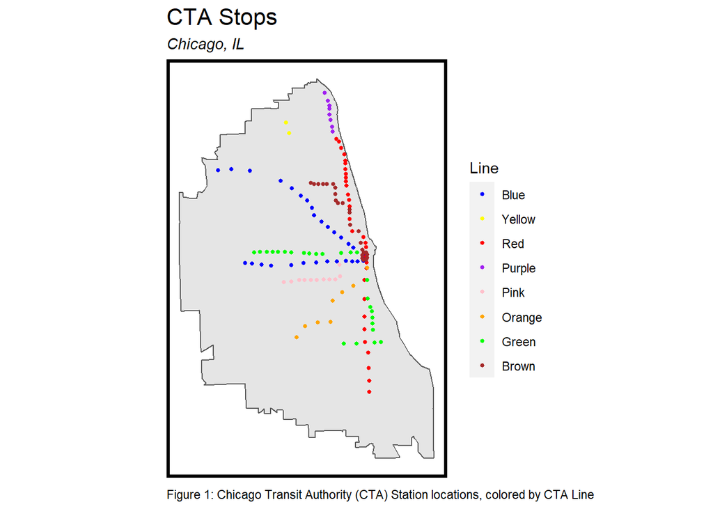

```r
#Add a new column to ctaStops to aggregate line names
changelevels <- function(f, ...) {
  f <- as.factor(f)
  levels(f) <- list(...)
  f
}

ctaStops$Line <-
  changelevels(ctaStops$LINES,
               Blue=c("Blue Line", "Blue Line (Congress)", "Blue Line (O'Hare)", "Brown, Orange, Pink, Purple (Express), Green, Blue"),
               Yellow=c("Yellow Line"),
               Red=c("Red Line", "Red, Brown, Purple (Express)", "Red, Yellow, Purple, Evanston Express"),
               Purple=c("Purple Line", "Purple Line, Evanston Express"),
               Pink=c("Pink"),
               Orange=c("Orange Line", "Orange & Green Lines"),
               Green=c("Green Line (Lake)", "Green Line (Englewood)", "Green Line", "Green (Lake), Pink"),
               Brown=c("Brown, Purple (Express)", "Brown, Orange, Pink, Purple (Express), Green, Blue", "Brown, Orange, Pink, Purple (Express)", "Brown, Orange, Pink,  Purple (Express), Green", "Brown Line"))

#Plot CTA Stations
ggplot() +
  geom_sf(data=st_union(tracts09_chi)) +
  geom_sf(data=ctaStops,
          aes(colour = Line),
          show.legend = "point", size= 1) +
  scale_colour_manual(values = c("blue","yellow","red", "purple", "pink","orange","green","brown")) +
  labs(title="CTA Stops",
       subtitle="Chicago, IL",
       caption="Figure 1: Chicago Transit Authority (CTA) Station locations, colored by CTA Line") +
  mapTheme()
```

Figure 1 depicts the distribution of CTA stations across the Chicago metropolitan area, colored by CTA line.

### Relate Census Data and Transit Data

This portion identifies which census tracts are located within a half-mile of a transit station.

```r
#Create 0.5 mile (2640 foot) buffer around each transit station
ctaBuffers <-
  rbind(
    st_buffer(ctaStops, 2640) %>%
      mutate(Legend = "Buffer") %>%
      dplyr::select(Legend),
    st_union(st_buffer(ctaStops, 2640)) %>%
      st_sf() %>%
      mutate(Legend = "Unioned Buffer"))

# Create an sf object with ONLY the unioned buffer
buffer <- filter(ctaBuffers, Legend=="Unioned Buffer")

# Use a centroid-in-polygon join identify tracts with their centroid in the buffer
selectCentroids <-
  st_centroid(tracts09_chi)[buffer,] %>%
  st_drop_geometry() %>%
  left_join(dplyr::select(tracts09_chi, GEOID)) %>%
  st_sf() %>%
  dplyr::select(TotalPop) %>%
  mutate(Selection_Type = "Select by Centroids")
allTracts.group <-
  rbind(
    st_centroid(allTracts)[buffer,] %>%
      st_drop_geometry() %>%
      left_join(allTracts) %>%
      st_sf() %>%
      mutate(TOD = "TOD"),
    st_centroid(allTracts)[buffer, op = st_disjoint] %>%
      st_drop_geometry() %>%
      left_join(allTracts) %>%
      st_sf() %>%
      mutate(TOD = "Non-TOD")) %>%
  mutate(MedRent.inf = ifelse(year == "2009", MedRent * 1.14, MedRent)) %>%
  mutate(pctBach.scaled = pctBachelors * 100)
```

```r
#Create Outline of TOD Tracts for use in mapping
TOD_Tracts <-
  allTracts.group%>%
    dplyr::select(TOD)%>%
  filter(TOD=="TOD")

TOD_Tracts_combined<-
  st_union(TOD_Tracts)%>%
      st_sf()
```

## Deliverable 2: Small Multiple Visualizations

This section creates a map of the TOD/non-TOD areas as well as four small multiple visualizations comparing the following U.S. Census variables across time and TOD/non-TOD locations: Median Rent, Total Population, Median Household Income, and Percent of the Population with a Bachelors Degree.

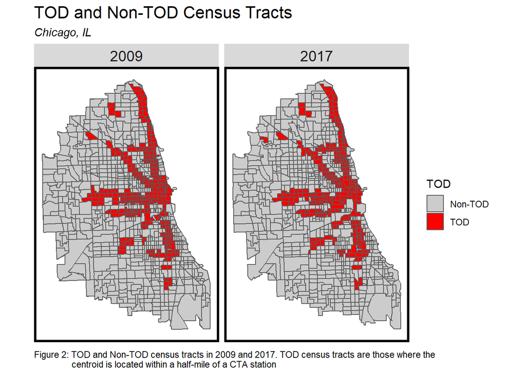

```r
# Small Multiple Plot: TOD/Non-TOD Map
ggplot(allTracts.group)+
  geom_sf(data = st_union(tracts17_chi))+
  geom_sf(aes(fill = TOD)) +
  scale_fill_manual(values = c("grey80","red")) +
  labs(title = "TOD and Non-TOD Census Tracts",
       subtitle="Chicago, IL",
       caption="Figure 2: TOD and Non-TOD census tracts in 2009 and 2017. TOD census tracts are those where the
                centroid is located within a half-mile of a CTA station") +
  facet_wrap(~year)+
  mapTheme()
```

Figure 2 depicts the TOD and non-TOD census tracts in 2009 and 2017. Because the extent, name, and location of census tracts can change over time, there are some slight differences between the TOD and non-TOD tracts in 2009 and 2017.

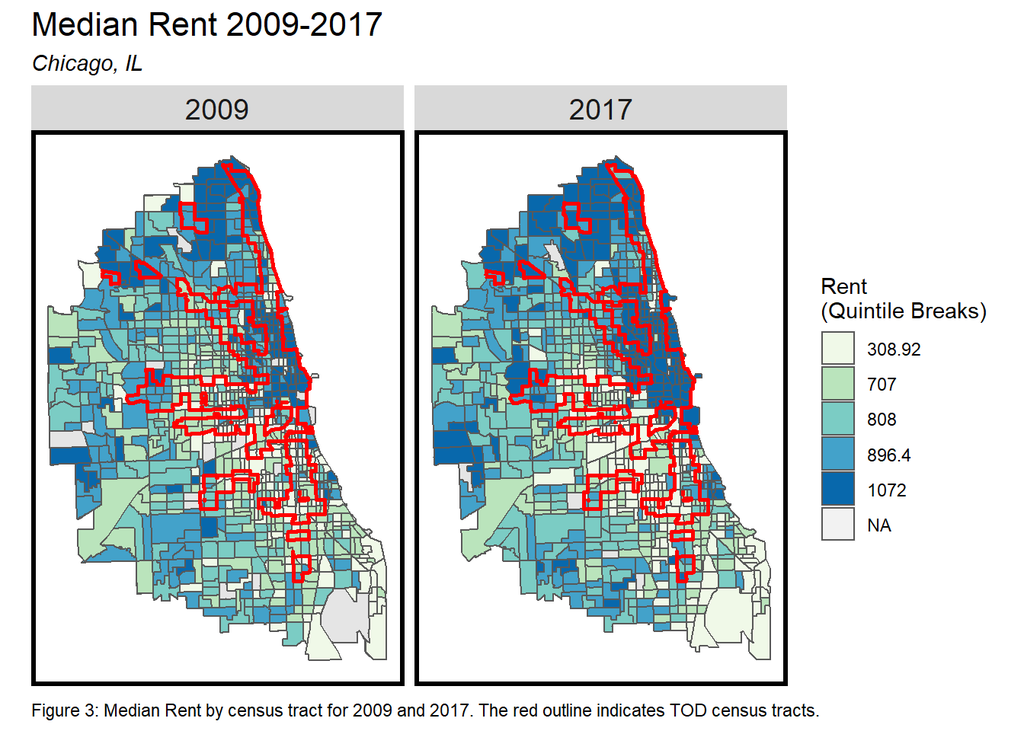

```r
#Small Multiple Plot: Median Rent over Time and Space
ggplot(allTracts.group)+
  geom_sf(data = st_union(tracts17_chi))+
  geom_sf(aes(fill = q5(MedRent.inf))) +
  geom_sf(data = TOD_Tracts_combined, fill = "transparent", color = "red", size =1)+
  scale_fill_manual(values = palette5,
                    labels = qBr(allTracts.group, "MedRent.inf"),
                    name = "Rent\n(Quintile Breaks)") +
  labs(title = "Median Rent 2009-2017",
       subtitle = "Chicago, IL",
       caption="Figure 3: Median Rent by census tract for 2009 and 2017. The red outline indicates TOD census tracts.") +
  facet_wrap(~year)+
  mapTheme()
```

Figure 3 depicts the distribution of median household rent in 2009 and 2017. In general, median rents increased over time. In particular, median rents in the TOD-regions of the downtown Chicago area increased (along the right edge of the map).

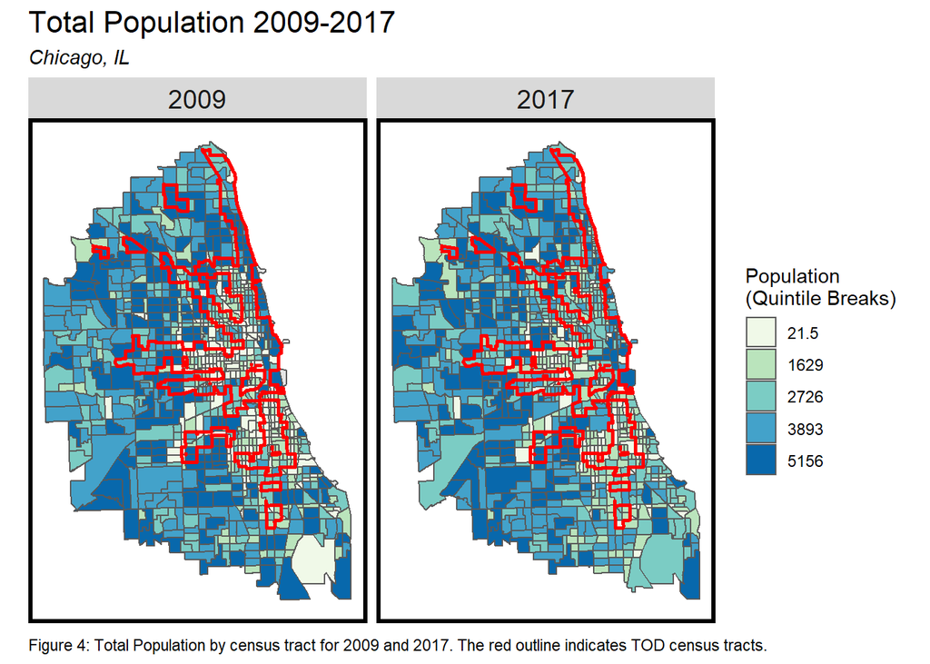

```r
# Small Multiple Plot: Total Population over Time and Space
ggplot(allTracts.group)+
  geom_sf(data = st_union(tracts17_chi))+
  geom_sf(aes(fill = q5(TotalPop))) +
  geom_sf(data = TOD_Tracts_combined, fill = "transparent", color = "red", size=1)+
  scale_fill_manual(values = palette5,
                    labels = qBr(allTracts.group, "TotalPop"),
                    name = "Population\n(Quintile Breaks)") +
  labs(title = "Total Population 2009-2017",
       subtitle="Chicago, IL",
       caption="Figure 4: Total Population by census tract for 2009 and 2017. The red outline indicates TOD census tracts.") +
  facet_wrap(~year)+
  mapTheme()
```

Figure 4 depicts the distribution of total population in 2009 and 2017. Overall, the location and magnitude of population remained largely the same over time.

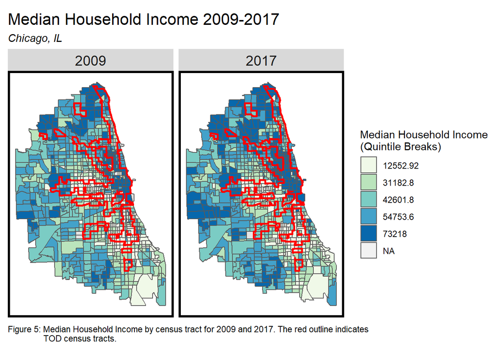

```r
# Small Multiple Plot: Median Household Income over Time and Space
ggplot(allTracts.group)+
  geom_sf(data = st_union(tracts17_chi))+
  geom_sf(aes(fill = q5(MedHHInc))) +
  geom_sf(data = TOD_Tracts_combined, fill = "transparent", color = "red", size=1)+
  scale_fill_manual(values = palette5,
                    labels = qBr(allTracts.group, "MedHHInc"),
                    name = "Median Household Income\n(Quintile Breaks)") +
  labs(title = "Median Household Income 2009-2017",
       subtitle = "Chicago, IL",
       caption="Figure 5: Median Household Income by census tract for 2009 and 2017. The red outline indicates
                TOD census tracts.") +
  facet_wrap(~year)+
  mapTheme()
```

Figure 5 depicts the distribution of median household income in 2009 and 2017. In general, median household income increased over time. In particular, median household income has increased in the TOD regions of the downtown Chicago area (along the right edge of the map).

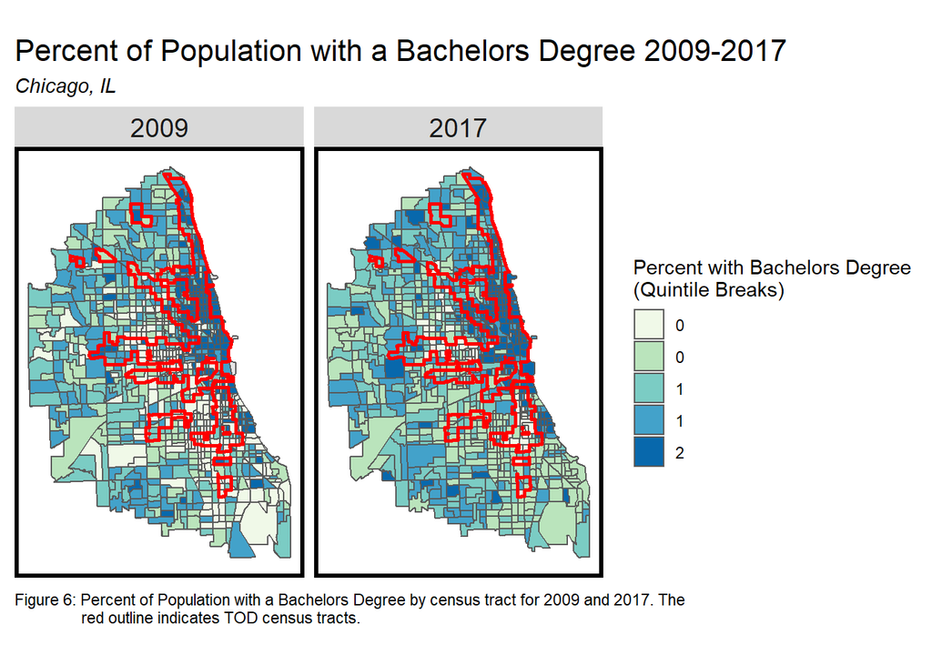

```r
# Small Multiple Plot: Higher-Education over Time and Space
ggplot(allTracts.group)+
  geom_sf(data = st_union(tracts17_chi))+
  geom_sf(aes(fill = q5(pctBach.scaled))) +
  geom_sf(data = TOD_Tracts_combined, fill = "transparent", color = "red", size =1)+
  scale_fill_manual(values = palette5,
                    labels = qBr(allTracts.group, "pctBach.scaled"),
                    name = "Percent with Bachelors Degree\n(Quintile Breaks)") +
  labs(title = "Percent of Population with a Bachelors Degree 2009-2017",
       subtitle="Chicago, IL",
       caption="Figure 6: Percent of Population with a Bachelors Degree by census tract for 2009 and 2017. The
                red outline indicates TOD census tracts.") +
  facet_wrap(~year)+
  mapTheme()
```

Figure 6 depicts the distribution of the percentage of the population with a bachelors degree for 2009 and 2017. In both time periods, the percentage of the population with a bachelors degree is greated in TOD census tracts than in non-TOD census tracts.

## Deliverable 3: Grouped Bar Plot

This section creates a grouped bar plot comparing the following U.S. Census variables across time and TOD/non-TOD locations: Median Rent, Total Population, Median Household Income, and Percent of the Population with a Bachelors Degree.

```r
allTracts.Summary <-
  st_drop_geometry(allTracts.group) %>%
  group_by(year, TOD) %>%
  summarize(Rent = mean(MedRent, na.rm = T),
            Population = mean(TotalPop, na.rm = T),
            Income = mean(MedHHInc, na.rm=T),
            Percent_Bachelors = mean(pctBach.scaled, na.rm = T))
```

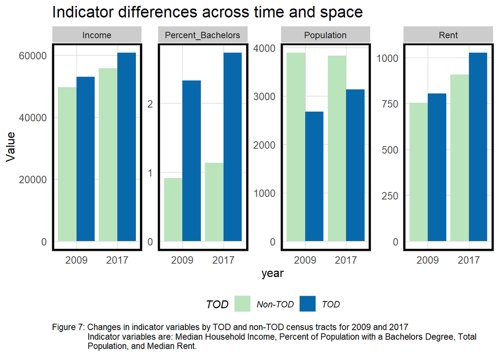

```r
allTracts.Summary %>%
  gather(Variable, Value, -year, -TOD) %>%
  ggplot(aes(year, Value, fill = TOD)) +
  geom_bar(stat = "identity", position = "dodge") +
  facet_wrap(~Variable, scales = "free", ncol=5) +
  scale_fill_manual(values = c("#bae4bc", "#0868ac")) +
  labs(title = "Indicator differences across time and space",
       caption="Figure 7: Changes in indicator variables by TOD and non-TOD census tracts for 2009 and 2017
                Indicator variables are: Median Household Income, Percent of Population with a Bachelors Degree, Total
                Population, and Median Rent.") +
  plotTheme() + theme(legend.position="bottom")+ theme(strip.text.x = element_text(size = 9))
```

Figure 7 provides a look across all of the indicators across space (TOD vs. non-TOD) and time (2009 vs. 2017). For both 2009 and 2017, median household income, percent of the population with a bachelors degree, and median rent are greater in TOD census tracts than in non-TOD census tracts. For all three of these variables, values increase between 2009 and 2017. However, total population is greater in non-TOD census tracts than in TOD census tract in both 2009 and 2017. Over time, total population slightly decreased for Non-TOD census tracts and increased for TOD Census Tracts.

## Deliverable 4: Summary Table

This section creates a summary table comparing the following U.S. Census variables across time and TOD/non-TOD locations: Median Income, Percent of the Population with a Bachelors Degree, Total Population, and Median Rent.

```r
allTracts.Summary %>%
  unite(year.TOD, year, TOD, sep = ": ", remove = T) %>%
  gather(Variable, Value, -year.TOD) %>%
  mutate(Value = round(Value, 2)) %>%
  spread(year.TOD, Value) %>%
  kable() %>%
  kable_styling() %>%
  footnote(general_title = "\n",
           general = "Table 1: Changes in indicator variables by TOD and non-TOD census tracts for 2009 and 2017
                Indicator variables are: Median Household Income, Percent of Population with a Bachelors Degree, Total
                Population, and Median Rent.")
```

| Variable | 2009: Non-TOD | 2009: TOD | 2017: Non-TOD | 2017: TOD |
| --- | --- | --- | --- | --- |
| Income | 49660.20 | 52972.85 | 55743.84 | 60847.14 |
| Percent_Bachelors | 0.92 | 2.33 | 1.14 | 2.73 |
| Population | 3898.86 | 2680.22 | 3834.90 | 3139.20 |
| Rent | 753.89 | 803.76 | 906.62 | 1027.64 |

Table 1: Changes in indicator variables by TOD and non-TOD census tracts for 2009 and 2017 Indicator variables are: Median Household Income, Percent of Population with a Bachelors Degree, Total Population, and Median Rent.

## Deliverable 5: Graduated Symbol Maps

This section creates two graduated symbol maps of population and rent within a half mile of each CTA station.

```r
ctaBuffers <-
    st_buffer(ctaStops, 2640) %>%
      mutate(Legend = "Buffer")

station_tracts <- st_intersection(allTracts, ctaBuffers)

Station_summary <-
  station_tracts %>%
  st_drop_geometry() %>%
  group_by(year, STATION_ID) %>%
  summarize(Population = sum(TotalPop),
            Rent = mean(MedRent, na.rm = T))%>%
  filter()
CTAStops_data <-
  left_join(ctaStops,Station_summary)
```

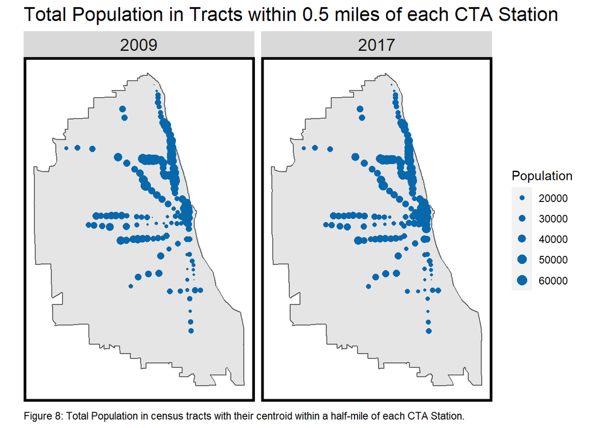

```r
ggplot(CTAStops_data)+
  geom_sf(data =st_union(tracts09_chi))+
  geom_sf(aes(size=Population), color="#0868ac")+
  scale_size_continuous(range=c(0,4))+
  labs(title = "Total Population in Tracts within 0.5 miles of each CTA Station",
       caption="Figure 8: Total Population in census tracts with their centroid within a half-mile of each CTA Station.")+
  facet_wrap(~year)+
  mapTheme()
```

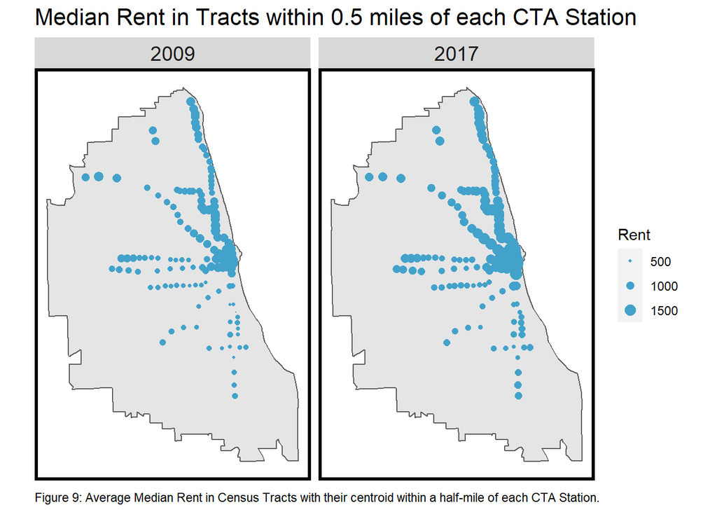

```r
ggplot(CTAStops_data)+
  geom_sf(data =st_union(tracts09_chi))+
  geom_sf(aes(size=Rent), color="#43a2ca")+
  scale_size_continuous(range=c(0,4))+
  labs(title = "Median Rent in Tracts within 0.5 miles of each CTA Station",
       caption="Figure 9: Average Median Rent in Census Tracts with their centroid within a half-mile of each CTA Station.")+
  facet_wrap(~year)+
  mapTheme()
```

## Deliverable 6: Rent as a Function of Distance to CTA Stations

This section analyzes mean rent as it relates to distance from CTA stations.

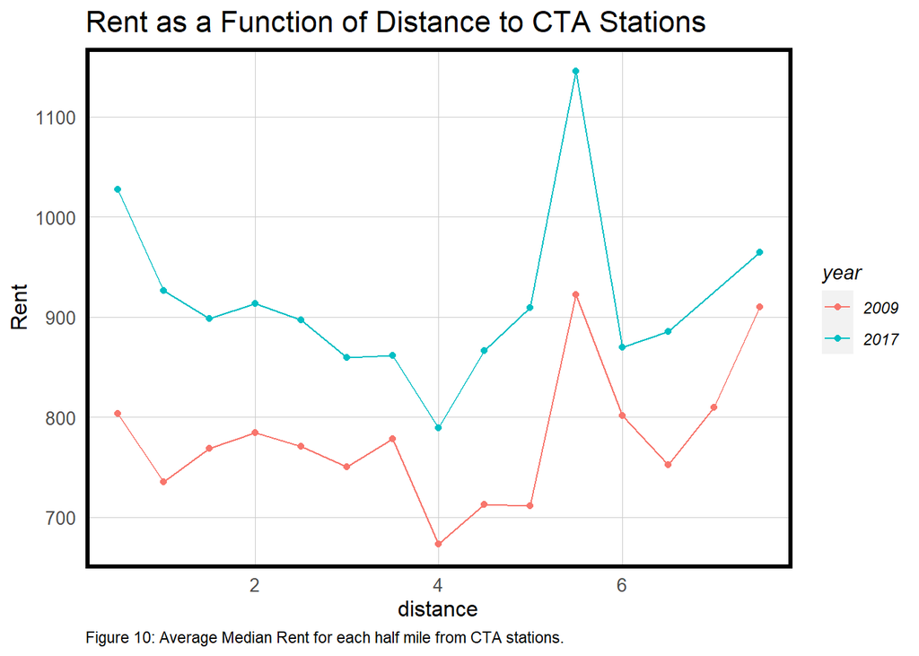

```r
square <- st_sfc(st_polygon(list(cbind(c(0,3,3,0,0),c(0,0,3,3,0)))))

  multipleRingBuffer <- function(inputPolygon, maxDistance, interval)
  {
    #create a list of distances that we'll iterate through to create each ring
    distances <- seq(0, maxDistance, interval)
    #we'll start with the second value in that list - the first is '0'
    distancesCounter <- 2
    #total number of rings we're going to create
    numberOfRings <- floor(maxDistance / interval)
    #a counter of number of rings
    numberOfRingsCounter <- 1
    #initialize an otuput data frame (that is not an sf)
    allRings <- data.frame()

    #while number of rings  counteris less than the specified nubmer of rings
    while (numberOfRingsCounter <= numberOfRings)
    {
      #if we're interested in a negative buffer and this is the first buffer
      #(ie. not distance = '0' in the distances list)
      if(distances[distancesCounter] < 0 & distancesCounter == 2)
      {
        #buffer the input by the first distance
        buffer1 <- st_buffer(inputPolygon, distances[distancesCounter])
        #different that buffer from the input polygon to get the first ring
        buffer1_ <- st_difference(inputPolygon, buffer1)
        #cast this sf as a polygon geometry type
        thisRing <- st_cast(buffer1_, "POLYGON")
        #take the last column which is 'geometry'
        thisRing <- as.data.frame(thisRing[,ncol(thisRing)])
        #add a new field, 'distance' so we know how far the distance is for a give ring
        thisRing$distance <- distances[distancesCounter]
      }


      #otherwise, if this is the second or more ring (and a negative buffer)
      else if(distances[distancesCounter] < 0 & distancesCounter > 2)
      {
        #buffer by a specific distance
        buffer1 <- st_buffer(inputPolygon, distances[distancesCounter])
        #create the next smallest buffer
        buffer2 <- st_buffer(inputPolygon, distances[distancesCounter-1])
        #This can then be used to difference out a buffer running from 660 to 1320
        #This works because differencing 1320ft by 660ft = a buffer between 660 & 1320.
        #bc the area after 660ft in buffer2 = NA.
        thisRing <- st_difference(buffer2,buffer1)
        #cast as apolygon
        thisRing <- st_cast(thisRing, "POLYGON")
        #get the last field
        thisRing <- as.data.frame(thisRing$geometry)
        #create the distance field
        thisRing$distance <- distances[distancesCounter]
      }

      #Otherwise, if its a positive buffer
      else
      {
        #Create a positive buffer
        buffer1 <- st_buffer(inputPolygon, distances[distancesCounter])
        #create a positive buffer that is one distance smaller. So if its the first buffer
        #distance, buffer1_ will = 0.
        buffer1_ <- st_buffer(inputPolygon, distances[distancesCounter-1])
        #difference the two buffers
        thisRing <- st_difference(buffer1,buffer1_)
        #cast as a polygon
        thisRing <- st_cast(thisRing, "POLYGON")
        #geometry column as a data frame
        thisRing <- as.data.frame(thisRing[,ncol(thisRing)])
        #add teh distance
        thisRing$distance <- distances[distancesCounter]
      }

      #rbind this ring to the rest of the rings
      allRings <- rbind(allRings, thisRing)
      #iterate the distance counter
      distancesCounter <- distancesCounter + 1
      #iterate the number of rings counter
      numberOfRingsCounter <- numberOfRingsCounter + 1
    }

    #convert the allRings data frame to an sf data frame
    allRings <- st_as_sf(allRings)
  }

buffers <- multipleRingBuffer(square, 10, 1)

#buffer created when we unioned into one sf object
buffersChi <- multipleRingBuffer(buffer, 47520, 2640)

#Uses a union of the ctaStops as the polygon instead of the unioned buffer
allTracts.rings <-
  st_join(st_centroid(dplyr::select(allTracts, GEOID, year)),
          multipleRingBuffer(st_union(ctaStops), 47520, 2640)) %>%
  st_drop_geometry() %>%
  left_join(dplyr::select(allTracts, GEOID, MedRent, year),
            by=c("GEOID"="GEOID", "year"="year")) %>%
  st_sf() %>%
  mutate(distance = distance / 5280) #convert to miles

allTracts.rings_summary <-
  allTracts.rings %>%
  st_drop_geometry() %>%
  group_by(distance, year)

allTracts.rings_summary <-
  allTracts.rings %>%
  st_drop_geometry() %>%
  group_by(distance, year) %>%
  summarize(Rent = mean(MedRent, na.rm=T))

ggplot(data=allTracts.rings_summary,
       aes(x = distance, y = Rent, colour = year)) + geom_point()+geom_line()+
  labs(title = "Rent as a Function of Distance to CTA Stations",
       caption="Figure 10: Average Median Rent for each half mile from CTA stations.")+
   plotTheme()
```

Figure 10 depicts the average median rent as a function of distance (in miles) from CTA stations. This plot does not indicate a strong overall trend. While rents immediately adjacent to CTA stations have relatively higher rents, there is large variation in rent prices overall.

## Deliverable 7: Crime Data Analysis

```r
#Crime data 2009
#Source: https://data.cityofchicago.org/Public-Safety/Crimes-2009/qqw2-hwkh
#Filter for Thefts only - can pick a different type if interested!
Crime09 <-
  st_read("https://data.cityofchicago.org/resource/qqw2-hwkh.geojson") %>%
  st_transform(crs='ESRI:102671') %>%
  mutate(crime_year = "2009") %>%
  filter(primary_type == "THEFT") %>%
  dplyr::select(primary_type, crime_year) %>%
  dplyr::select(-geometry)
```

```
## replacing null geometries with empty geometries
## Simple feature collection with 1000 features and 21 fields (with 216 geometries empty)
## geometry type:  POINT
## dimension:      XY
## bbox:           xmin: -87.84154 ymin: 41.65329 xmax: -87.52696 ymax: 42.00917
## geographic CRS: WGS 84
```

```r
#Crime data 2017
#Scource: https://data.cityofchicago.org/Public-Safety/Crimes-2017/d62x-nvdr
#Filter for Thefts only - can pick a different type if interested!
Crime17 <-
  st_read("https://data.cityofchicago.org/resource/d62x-nvdr.geojson")%>%
  st_transform(crs='ESRI:102671') %>%
  mutate(crime_year = "2017") %>%
  filter(primary_type == "THEFT") %>%
  dplyr::select(primary_type, crime_year) %>%
  dplyr::select(-geometry)
```

```
## replacing null geometries with empty geometries
## Simple feature collection with 1000 features and 33 fields (with 35 geometries empty)
## geometry type:  POINT
## dimension:      XY
## bbox:           xmin: -87.90523 ymin: 41.65184 xmax: -87.52565 ymax: 42.02113
## geographic CRS: WGS 84
```

```r
#Combine 2009 and 2017 Crime Data
AllCrime <- rbind(Crime09, Crime17)

#Join Crime with Census Tract
AllCrime_join <-
  st_join(AllCrime,allTracts.group) %>%
  filter(crime_year == year)%>%
  dplyr::select(primary_type, crime_year, year, GEOID, TOD)

#Count crimes in each census tract
Crime_tract <-
  st_drop_geometry(AllCrime_join) %>%
  group_by(GEOID,year) %>%
  summarize(Thefts=n())
#Count crimes by year and TOD
Crime_year_TOD<-
  st_drop_geometry(AllCrime_join) %>%
  group_by(TOD, year) %>%
  summarize(Thefts=n())
#Join Crime Counts with AllTracts.group
AllTracts.group.crime<-
  left_join(allTracts.group,Crime_tract,)
#Summary tables for crime
allTracts.Crime.Summary <-
  AllTracts.group.crime %>%
  st_drop_geometry() %>%
  group_by(year, TOD) %>%
  summarize(Rent = mean(MedRent, na.rm = T),
            Thefts = sum(Thefts, na.rm = T))
allTracts.Crime.Summary %>%
  unite(year.TOD, year, TOD, sep = ": ", remove = T) %>%
  gather(Variable, Value, -year.TOD) %>%
  mutate(Value = round(Value, 2)) %>%
  spread(year.TOD, Value) %>%
  kable() %>%
  kable_styling() %>%
  footnote(general_title = "\n",
           general = "Table 2: Relationship between median rent and number of thefts over time and space.")
```

| Variable | 2009: Non-TOD | 2009: TOD | 2017: Non-TOD | 2017: TOD |
| --- | --- | --- | --- | --- |
| Rent | 753.89 | 803.76 | 906.62 | 1027.64 |
| Thefts | 107.00 | 75.00 | 101.00 | 118.00 |

Table 2: Relationship between median rent and number of thefts over time and space.

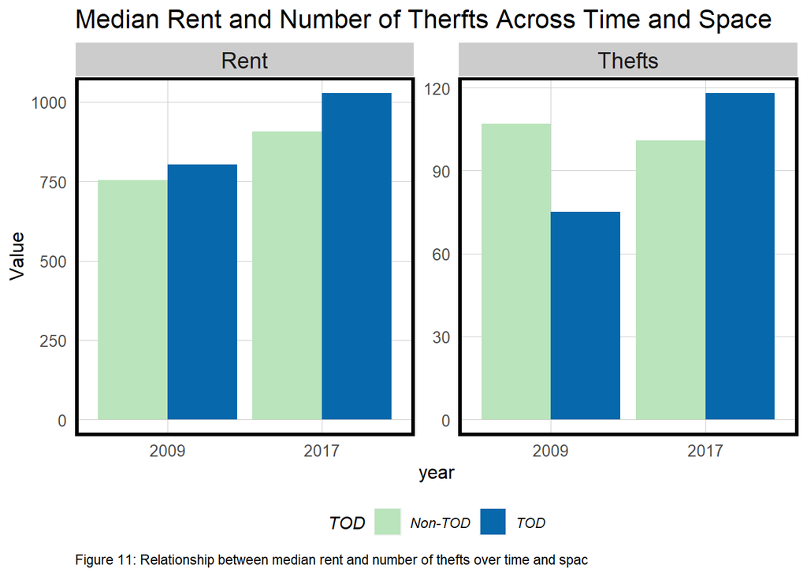

```r
#Small Multiple Plots
allTracts.Crime.Summary %>%
  gather(Variable, Value, -year, -TOD) %>%
  ggplot(aes(year, Value, fill = TOD)) +
  geom_bar(stat = "identity", position = "dodge") +
  facet_wrap(~Variable, scales = "free", ncol=5) +
  scale_fill_manual(values = c("#bae4bc", "#0868ac")) +
  labs(title = "Median Rent and Number of Therfts Across Time and Space",
       caption="Figure 11: Relationship between median rent and number of thefts over time and spac") +
  plotTheme() + theme(legend.position="bottom")
```

# Conclusions

Overall, the results from this Chicago TOD analysis suggest that residents of Chicago may value transit-rich neighborhoods over other neighborhoods. However, it is important to consider the uncertainties and spatial biases that are inherent to the analysis when uses the results to inform decision-making.

**Population Change:** The fact that over time, population increased in TOD census tracts while decreasing in non-TOD census tracts suggests that Chicago residents prefer to live in transit rich areas.

**Income and Rent:** In both 2009 and 2017, both median incomes and median rents were higher in TOD census tracts than in non-TOD census tracts. The fact that median rents are higher in TOD areas suggest that at least some portion of renters are willing to pay more to live in transit-rich areas. The households located in TOD census tracts have higher median incomes than in non-TOD census tracts, suggesting that those who prefer to live in transit-rich areas are more affulent than those who live in other areas.

**Education Level and TOD Preferences:** Across both time periods, the percentage of the population with a bachelors degree is higher in TOD census tracts than in non-TOD census tracts. This result provides a glimpse into the demographics of Chicago residents who prefer to live in TOD areas; namely, those who prefer TOD areas may be more highly educated than other citizens.

**Crime and TOD Areas:** The analysis suggests that between 2009 and 2017, the number of thefts increased in TOD areas and decreased in non-TOD areas. It may be possible to explain this change based on the change in population: over time, total population in TOD areas has increased, which total population in non-TOD areas has decreased. The number of thefts does not seem to be strongly related to rents in TOD areas.

**Uncertainties and Spatial Biases:** Because the analysis uses data at the census tract level, which are arbitrarily drawn and introduces the Modifiable Areal Unit Problem. This analysis compares census tracts between 2009 and 2017. During this time period, the boundaries and/or names of some census tracts may have changed, which introduces some error into our results.